# PA1_template.Rmd

AG

Sunday, October 11, 2015

# Overview

*It is now possible to collect a large amount of data about personal movement using activity monitoring devices such as a [Fitbit](http://www.fitbit.com/), [Nike] (http://www.nike.com/)[Fuelband](http://www.fuelband.com/), or [Jawbone](http://www.jawbone.com/) Up. These type of devices are part of the “quantified self” movement - a group of enthusiasts who take measurements about themselves regularly to improve their health, to find patterns in their behavior, or because they are tech geeks. But these data remain under-utilized both because the raw data are hard to obtain and there is a lack of statistical methods and software for processing and interpreting the data.*

This document tries to illustrate the average steps taken in a day , daily pattern and also tries to explore if there differences during weekdays and weekends. This is based of the the [“Activity” dataset](https://d396qusza40orc.cloudfront.net/repdata%2Fdata%2Factivity.zip), provided as a part of Assignment 1 of Reproducibel Research course at JHU.

## Let us read the dataset now

I’ve set the working directory to the location where the activity.csv file is located. Before we read the dataset, want to load the *ggplot2* library for plotting. You can see the code below

```r
library(ggplot2)
library(chron)
activitydata <-read.csv("./activity.csv", head=TRUE, sep=",")
```

### Let us look at the activitydata

```r
head(activitydata)
```

```
##   steps       date interval
## 1    NA 2012-10-01        0
## 2    NA 2012-10-01        5
## 3    NA 2012-10-01       10
## 4    NA 2012-10-01       15
## 5    NA 2012-10-01       20
## 6    NA 2012-10-01       25
```

```r
sapply(activitydata, class)
```

```
##     steps      date  interval
## "integer"  "factor" "integer"
```

## Question 1: What is mean total number of steps taken per day?

Data is collected at specific intervals, everyday for 2 months. We need to sum all the steps taken per day, before we get the mean and corresponding median.

```r
stepsbyday<-tapply(activitydata$steps, activitydata$date,sum)
```

Now let us plot the steps by day

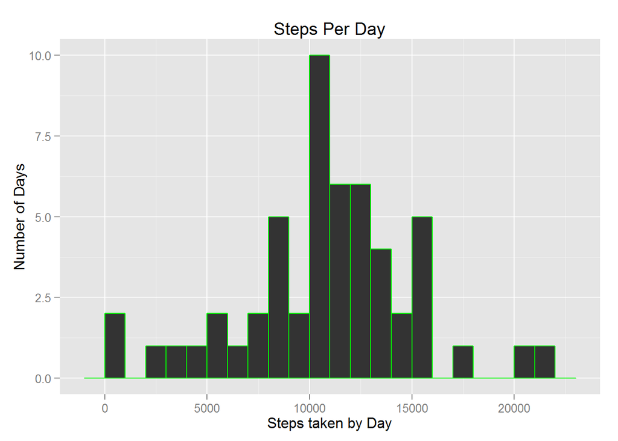

```r
g<-ggplot(as.data.frame(stepsbyday), aes(stepsbyday))
g+geom_histogram(binwidth = 1000, col="green") + labs( x="Steps taken by Day", y="Number of Days", title = "Steps Per Day")
```

Also, the average number of steps across days is found to be

```r
mean(stepsbyday, na.rm=TRUE)
```

```
## [1] 10766.19
```

And the median of number of steps is

```r
median(stepsbyday, na.rm=TRUE)
```

```
## [1] 10765
```

## Question 2: What is the average daily activity pattern?

So, we need to see how people walk around, on an average, during the day.. First, let us clean up the data a bit

```r
cleandata<-subset(activitydata, !is.na(activitydata$steps))
avgdailypattern<-tapply(cleandata$steps, cleandata$interval, mean)
```

Let us plot the time series data now

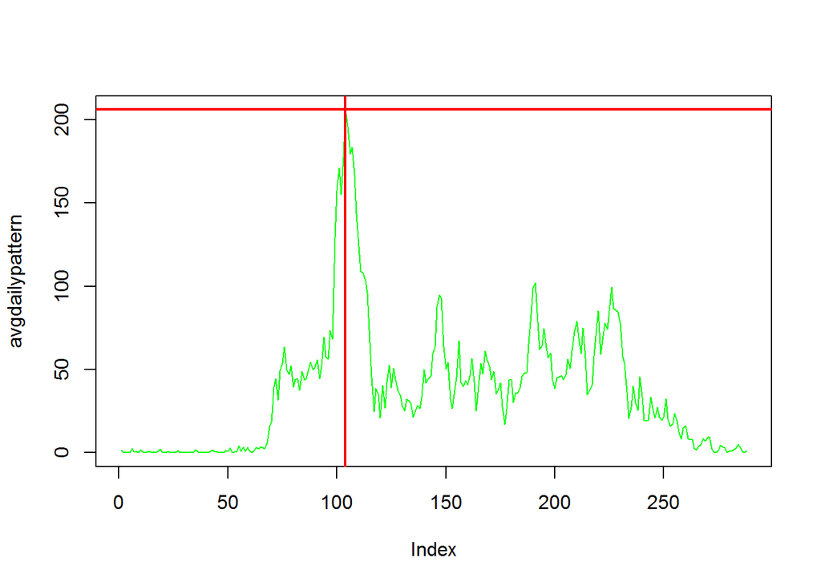

```r
plot(avgdailypattern, type="l", col="green")
abline(v=which.max(avgdailypattern)[[1]], col ="red", lwd=2)
abline(h=max(avgdailypattern), col="red", lwd=2)
```

```r
which.max(avgdailypattern)[[1]]
```

```
## [1] 104
```

## Question 3 Imputing Missing Values

As the first part of the question, let us look at the number of missing values in the data set

[output not shown]

So, all we need is to compute the missing values for steps feature. Let us see how many days have NA values

```r
NADays<-tapply(activitydata$steps, activitydata$date, function(x) sum(is.na(x)))
```

Let us see how many days have NA values

```r
length(which(NADays!=0))
```

```
## [1] 8
```

Let us impute values into the data set, now. Will adopt a very simple technique of inserting “mean” number of steps / interval into the data set

Let us massage the data set

```r
data1<-subset(activitydata, !is.na(activitydata$steps))
data2<-subset(activitydata, is.na(activitydata$steps))
steppat<-tapply(data1$steps, data1$interval, mean)
data2$steps<-steppat
data3<-rbind(data1, data2)
stepsbyday1<- tapply(data3$steps, data3$date, sum)
```

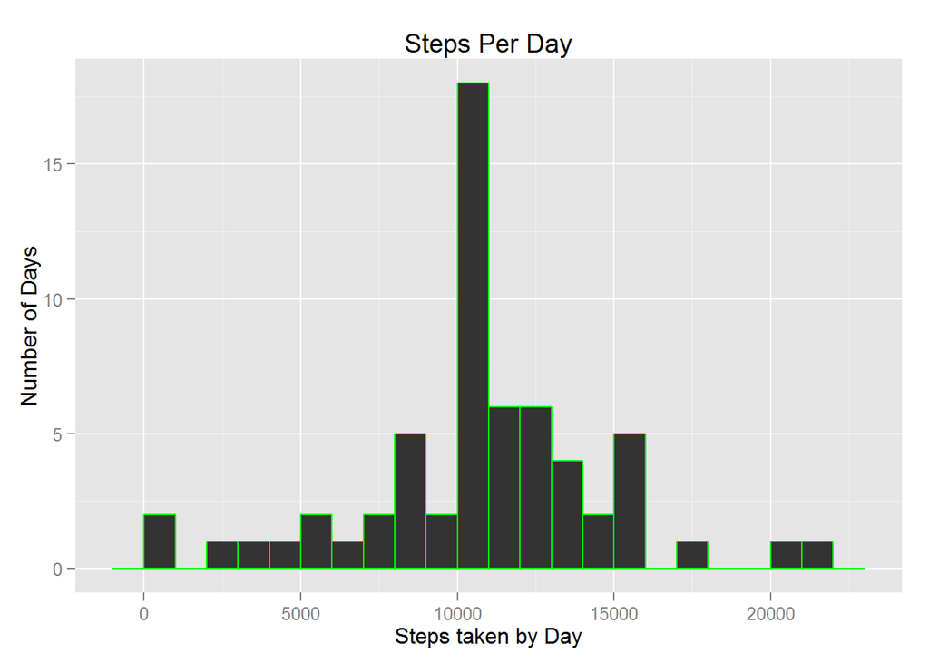

```r
g<-ggplot(as.data.frame(stepsbyday1), aes(stepsbyday1))
g+geom_histogram(binwidth = 1000, col="green") + labs( x="Steps taken by Day", y="Number of Days", title = "Steps Per Day")
```

Mean and Meadian values, below

```r
mean(stepsbyday1)
```

```
## [1] 10766.19
```

```r
median(stepsbyday1)
```

```
## [1] 10766.19
```

## Question 4: Are there differences in activity patterns between weekdays and weekends?

Let us create a factor variable to indicate weekdays vs weekends

```r
activitydata$date<-as.POSIXlt(activitydata$date, format="%Y-%m-%d")
activitydata$weekend<-is.weekend(activitydata$date)
table(activitydata$weekend)
```

```
##
## FALSE  TRUE
## 12960  4608
```

Let us plot the weekday Vs Weekend pattern

```r
activitydata<-subset(activitydata, !is.na(activitydata$steps))
weekdaypat<-subset(activitydata, !activitydata$weekend)
weekendpat<-subset(activitydata, activitydata$weekend)
wkdyavg<-tapply(weekdaypat$steps, weekdaypat$interval, mean)
wkndavg<-tapply(weekendpat$steps, weekendpat$interval, mean)
```

Let us plot the patterns

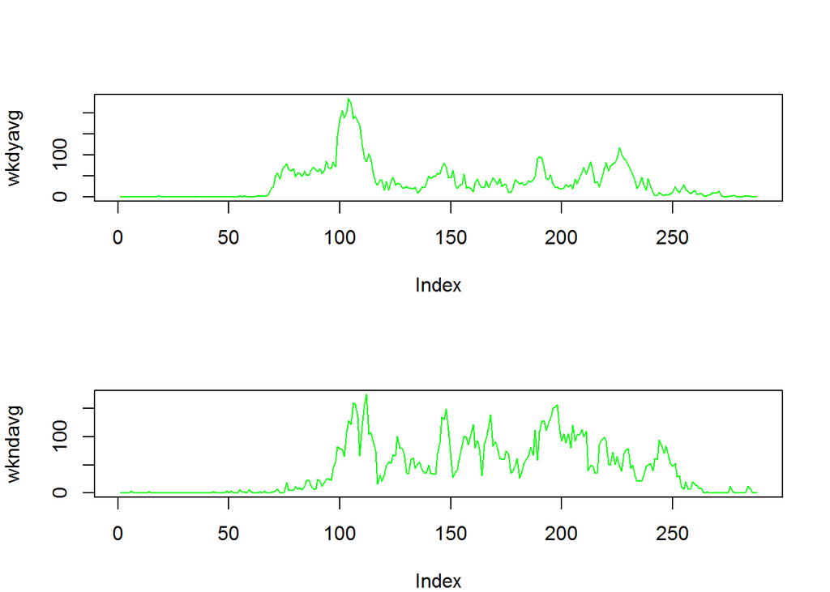

```r
par(mfrow=c(2,1), mar= c(4,4,4,2))
plot(wkdyavg, type="l", col="green", title="Weekdays")
plot(wkndavg, type="l", col="green", title="Weekends")
```